# WHITE-WINE QUALITY ANALYSIS BY NARDOS NEGUSSE

I chose the white wine dataset for doing exploratory data analysis using R to find out the effect of each variable to the quality of white wine.The dataset is related to white variant of the Portuguese “Vinho Verde” wine.http://www.vinhoverde.pt/en/

Input variables white wine (based on physicochemical tests) are:

1 - fixed acidity (tartaric acid - g / dm^3)

2 - volatile acidity (acetic acid - g / dm^3)

3 - citric acid (g / dm^3)

4 - residual sugar (g / dm^3)

5 - chlorides (sodium chloride - g / dm^3

6 - free sulfur dioxide (mg / dm^3)

7 - total sulfur dioxide (mg / dm^3)

8 - density (g / cm^3)

9 - pH

10 - sulphates (potassium sulphate - g / dm3)

11 - alcohol (% by volume)

The output variable (based on sensory data) is: 12 - quality (score between 0 and 10)

# Univariate Plots Section

There are 4898 instances and 11 (+ output) attributes in the white wine dataset.

```
## 'data.frame':    4898 obs. of  13 variables:
##  $ X                   : int  1 2 3 4 5 6 7 8 9 10 ...
##  $ fixed.acidity       : num  7 6.3 8.1 7.2 7.2 8.1 6.2 7 6.3 8.1 ...
##  $ volatile.acidity    : num  0.27 0.3 0.28 0.23 0.23 0.28 0.32 0.27 0.3 0.22 ...
##  $ citric.acid         : num  0.36 0.34 0.4 0.32 0.32 0.4 0.16 0.36 0.34 0.43 ...
##  $ residual.sugar      : num  20.7 1.6 6.9 8.5 8.5 6.9 7 20.7 1.6 1.5 ...
##  $ chlorides           : num  0.045 0.049 0.05 0.058 0.058 0.05 0.045 0.045 0.049 0.044 ...
##  $ free.sulfur.dioxide : num  45 14 30 47 47 30 30 45 14 28 ...
##  $ total.sulfur.dioxide: num  170 132 97 186 186 97 136 170 132 129 ...
##  $ density             : num  1.001 0.994 0.995 0.996 0.996 ...
##  $ pH                  : num  3 3.3 3.26 3.19 3.19 3.26 3.18 3 3.3 3.22 ...
##  $ sulphates           : num  0.45 0.49 0.44 0.4 0.4 0.44 0.47 0.45 0.49 0.45 ...
##  $ alcohol             : num  8.8 9.5 10.1 9.9 9.9 10.1 9.6 8.8 9.5 11 ...
##  $ quality             : int  6 6 6 6 6 6 6 6 6 6 ...
```

```
##  [1] "X"                    "fixed.acidity"        "volatile.acidity"
##  [4] "citric.acid"          "residual.sugar"       "chlorides"
##  [7] "free.sulfur.dioxide"  "total.sulfur.dioxide" "density"
## [10] "pH"                   "sulphates"            "alcohol"
## [13] "quality"
```

```
##  fixed.acidity    volatile.acidity  citric.acid     residual.sugar
##  Min.   : 3.800   Min.   :0.0800   Min.   :0.0000   Min.   : 0.600
##  1st Qu.: 6.300   1st Qu.:0.2100   1st Qu.:0.2700   1st Qu.: 1.700
##  Median : 6.800   Median :0.2600   Median :0.3200   Median : 5.200
##  Mean   : 6.855   Mean   :0.2782   Mean   :0.3342   Mean   : 6.391
##  3rd Qu.: 7.300   3rd Qu.:0.3200   3rd Qu.:0.3900   3rd Qu.: 9.900
##  Max.   :14.200   Max.   :1.1000   Max.   :1.6600   Max.   :65.800
##    chlorides       free.sulfur.dioxide total.sulfur.dioxide
##  Min.   :0.00900   Min.   :  2.00      Min.   :  9.0
##  1st Qu.:0.03600   1st Qu.: 23.00      1st Qu.:108.0
##  Median :0.04300   Median : 34.00      Median :134.0
##  Mean   :0.04577   Mean   : 35.31      Mean   :138.4
##  3rd Qu.:0.05000   3rd Qu.: 46.00      3rd Qu.:167.0
##  Max.   :0.34600   Max.   :289.00      Max.   :440.0
##     density             pH          sulphates         alcohol
##  Min.   :0.9871   Min.   :2.720   Min.   :0.2200   Min.   : 8.00
##  1st Qu.:0.9917   1st Qu.:3.090   1st Qu.:0.4100   1st Qu.: 9.50
##  Median :0.9937   Median :3.180   Median :0.4700   Median :10.40
##  Mean   :0.9940   Mean   :3.188   Mean   :0.4898   Mean   :10.51
##  3rd Qu.:0.9961   3rd Qu.:3.280   3rd Qu.:0.5500   3rd Qu.:11.40
##  Max.   :1.0390   Max.   :3.820   Max.   :1.0800   Max.   :14.20
```

Let’s plot all the variables so as to have the general understanding of the distributions (to visualize the features) of all the attributes in our data set.

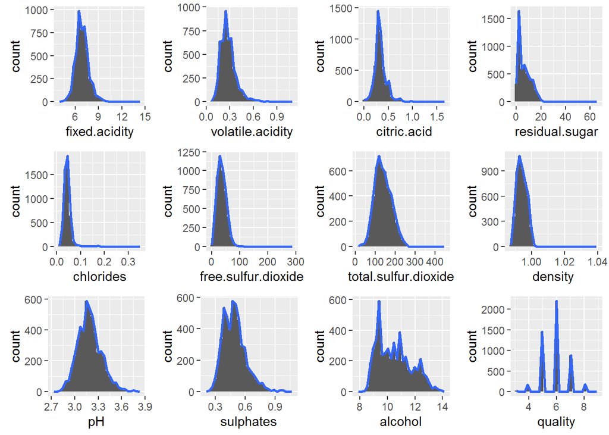

The above plots reveals that PH, Sulphates, Alcohol and Quality are roughly normally distributed and fixed acidity, volitile acidity, chlorides, density, Citric acid, residual sugar are some what skewed to the right (long-right-tail). Some adjustments will be done to the variables that the observations are not normally distributed.

##### Fixed Acidity

```
##    Min. 1st Qu.  Median    Mean 3rd Qu.    Max.
##   3.800   6.300   6.800   6.855   7.300  14.200
```

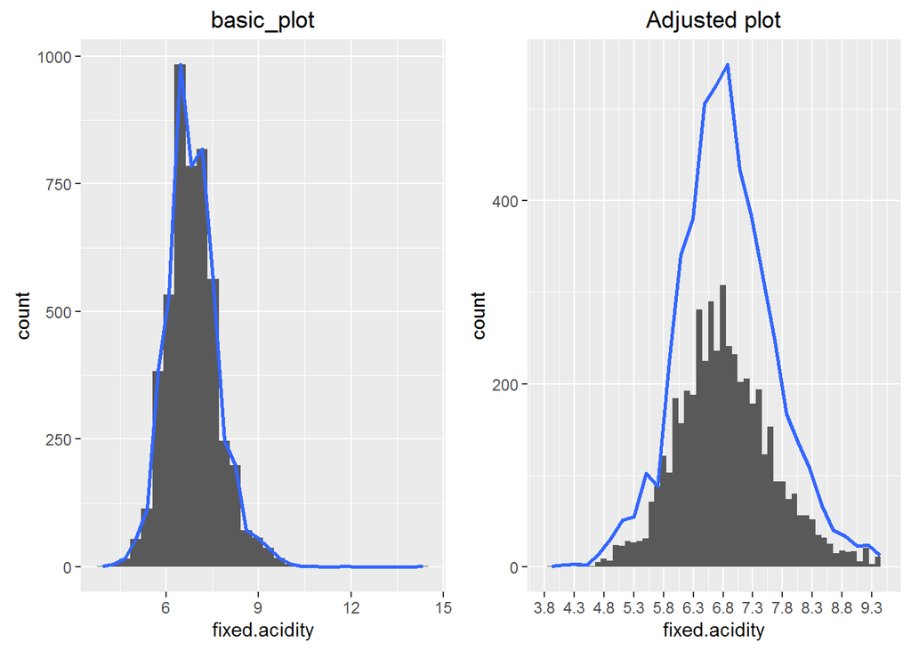

Volitile Acidity

```
##    Min. 1st Qu.  Median    Mean 3rd Qu.    Max.
##  0.0800  0.2100  0.2600  0.2782  0.3200  1.1000
```

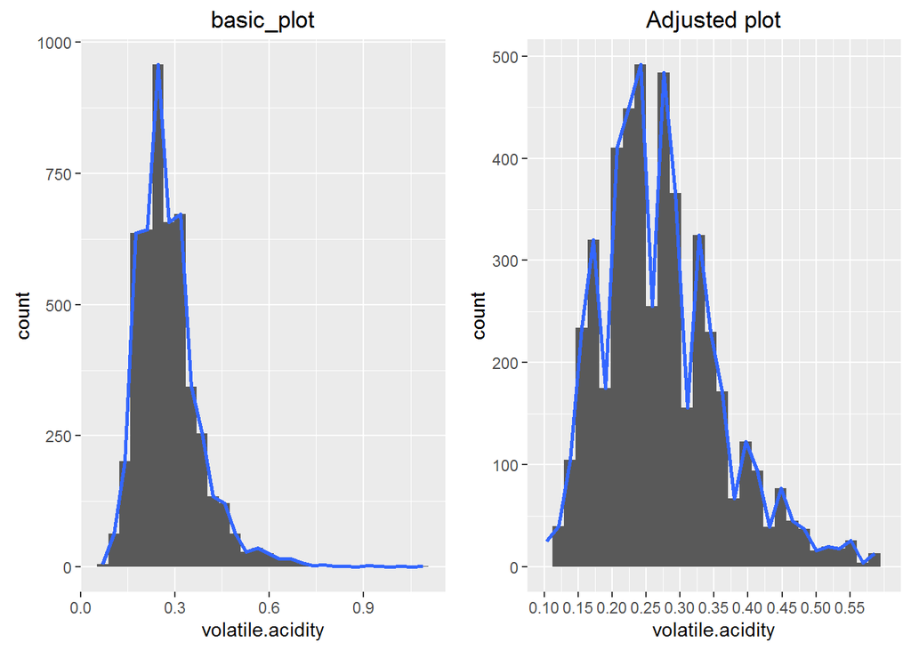

##### Citric Acid

```
##    Min. 1st Qu.  Median    Mean 3rd Qu.    Max.
##  0.0000  0.2700  0.3200  0.3342  0.3900  1.6600
```

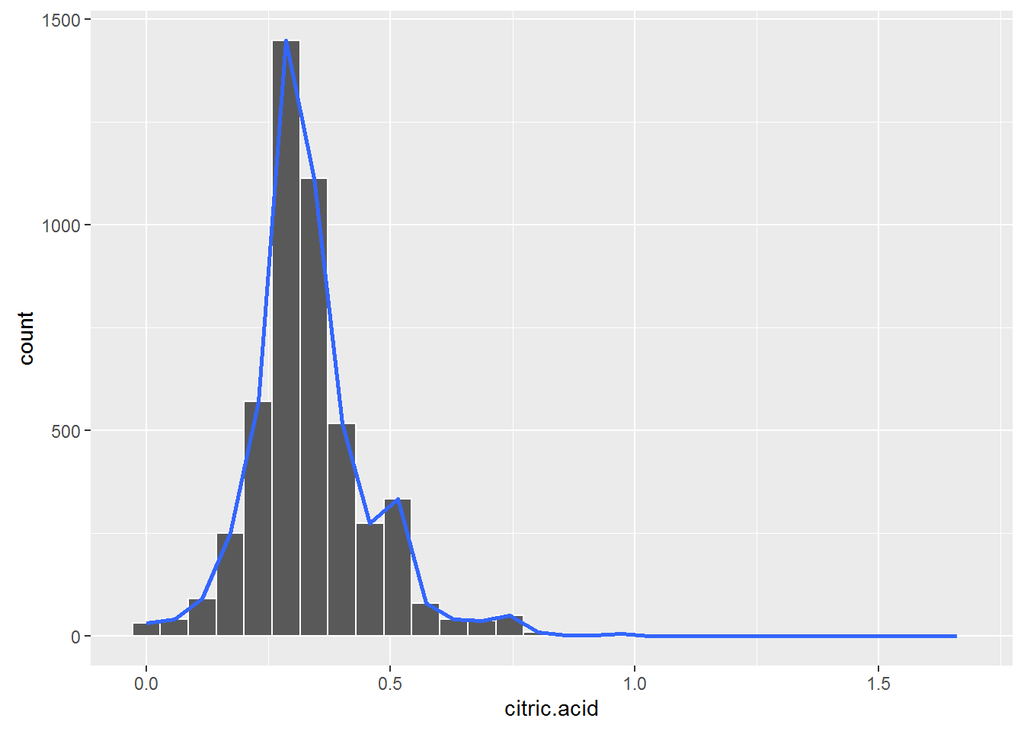

Citric acid shows a long positive tail distribution. In the range of 0 to 0.8 g/dm3, the distribution appears to be normal. There are few points above 0.8 that can be considered as outliers. Some of the wines have no citric acid added as well.

Residual Sugar

```
##    Min. 1st Qu.  Median    Mean 3rd Qu.    Max.
##   0.600   1.700   5.200   6.391   9.900  65.800
```

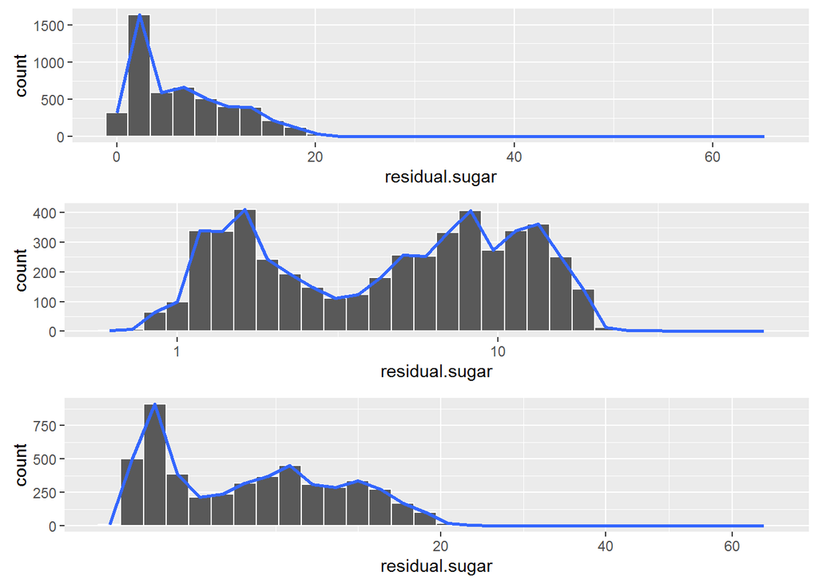

The residual sugar distribution in white wines is highly skewed to the right (with a wide range of 0.6 g/l and 65.8 g/l). Perhaps this could be due to peoples’ preferences of wines with different level of sweetness in wine. The average sugar level in white wine is 6.39g/l and a median of 5.2g/l and with a peak of between 1 to 2g/l. Inorder to make residual sugar observations normally distributed, both logarithmic (base 10) and square root transformations is done, in which the log transformation prefered to be the best one. Hence,residual sugar observations ended up being a bimodal distribution, almost grouped into less sweeter and more sweeter wines.

Density

```
##    Min. 1st Qu.  Median    Mean 3rd Qu.    Max.
##  0.9871  0.9917  0.9937  0.9940  0.9961  1.0390
```

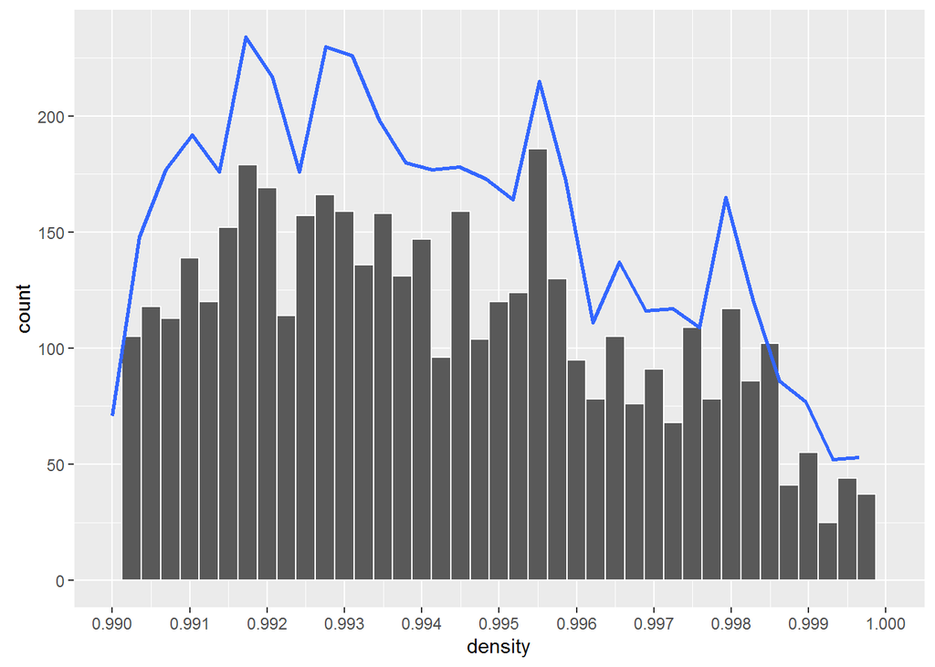

The density distribution is positively skewed. It has a mean of 0.994g/cc and a median of 0.9937g/cc. Observations above 1.0g/cc are considered outliers in order to have normally distributed density observations in a range of 0.99 and 1.0g/cc.

Addition of a new variable

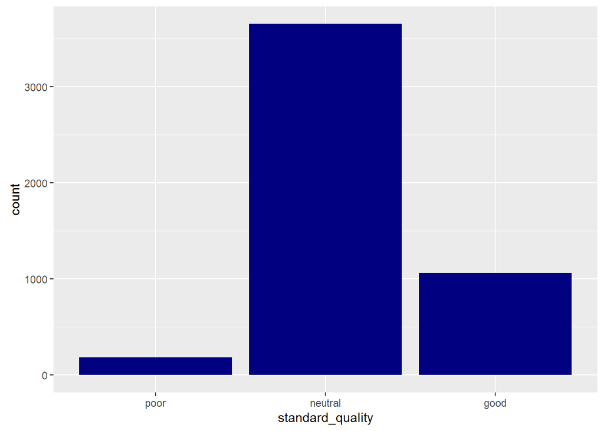

# Univariate Analysis

### The main feature(s) of interest

I found wine quality the most important feature in this dataset. I am curious to find out the relationship of the different variables and their effect in the quality of wine.

### Formation of new variable from existing variable

I created a new factor variable by taking in to account the different categories of quality rating and came up with three groups namely; poor, neutral and good.

### Adjustment of unusual distributions

Eventhough plots taken roughly shows majority of the instances to be normally distributed, a closer look at each variable reveals the need for adjustments. I found distribution of fixed acidity, volitile acidity, chlorides, density, Citric acid, and residual sugar to be skewed to the right. I performed adjustments like binwidth, limit, logarithmic (base 10) and square root to various variables according the distribution and shape of their observations.

The variable Residual sugar, for example, had an unsual distribution where the observations ranges from range from 0.6 grams/liter to 65.8 grams/liter and is highly skewed to the right. I performed log transformation and I realized it is a bimodal distribution with two peaks at about 2grams/liter and at about 9 grams/liter.

# Bivariate Plots Section

correlation coefficient between all attributes

```
##                      fixed.acidity volatile.acidity citric.acid
## fixed.acidity           1.00000000      -0.02269729  0.28918070
## volatile.acidity       -0.02269729       1.00000000 -0.14947181
## citric.acid             0.28918070      -0.14947181  1.00000000
## residual.sugar          0.08902070       0.06428606  0.09421162
## chlorides               0.02308564       0.07051157  0.11436445
## free.sulfur.dioxide    -0.04939586      -0.09701194  0.09407722
## total.sulfur.dioxide    0.09106976       0.08926050  0.12113080
## density                 0.26533101       0.02711385  0.14950257
## pH                     -0.42585829      -0.03191537 -0.16374821
## sulphates              -0.01714299      -0.03572815  0.06233094
## alcohol                -0.12088112       0.06771794 -0.07572873
##                      residual.sugar   chlorides free.sulfur.dioxide
## fixed.acidity            0.08902070  0.02308564       -0.0493958591
## volatile.acidity         0.06428606  0.07051157       -0.0970119393
## citric.acid              0.09421162  0.11436445        0.0940772210
## residual.sugar           1.00000000  0.08868454        0.2990983537
## chlorides                0.08868454  1.00000000        0.1013923521
## free.sulfur.dioxide      0.29909835  0.10139235        1.0000000000
## total.sulfur.dioxide     0.40143931  0.19891030        0.6155009650
## density                  0.83896645  0.25721132        0.2942104109
## pH                      -0.19413345 -0.09043946       -0.0006177961
## sulphates               -0.02666437  0.01676288        0.0592172458
## alcohol                 -0.45063122 -0.36018871       -0.2501039415
##                      total.sulfur.dioxide     density            pH
## fixed.acidity                 0.091069756  0.26533101 -0.4258582910
## volatile.acidity              0.089260504  0.02711385 -0.0319153683
## citric.acid                   0.121130798  0.14950257 -0.1637482114
## residual.sugar                0.401439311  0.83896645 -0.1941334540
## chlorides                     0.198910300  0.25721132 -0.0904394560
## free.sulfur.dioxide           0.615500965  0.29421041 -0.0006177961
## total.sulfur.dioxide          1.000000000  0.52988132  0.0023209718
## density                       0.529881324  1.00000000 -0.0935914935
## pH                            0.002320972 -0.09359149  1.0000000000
## sulphates                     0.134562367  0.07449315  0.1559514973
## alcohol                      -0.448892102 -0.78013762  0.1214320987
##                        sulphates     alcohol
## fixed.acidity        -0.01714299 -0.12088112
## volatile.acidity     -0.03572815  0.06771794
## citric.acid           0.06233094 -0.07572873
## residual.sugar       -0.02666437 -0.45063122
## chlorides             0.01676288 -0.36018871
## free.sulfur.dioxide   0.05921725 -0.25010394
## total.sulfur.dioxide  0.13456237 -0.44889210
## density               0.07449315 -0.78013762
## pH                    0.15595150  0.12143210
## sulphates             1.00000000 -0.01743277
## alcohol              -0.01743277  1.00000000
```

The following correlation coefficient table indicates the magnitute and direction of correlation between all input attributes and the output vairable (Quality).

```
##                              [,1]
## fixed.acidity        -0.113662831
## volatile.acidity     -0.194722969
## citric.acid          -0.009209091
## residual.sugar       -0.097576829
## chlorides            -0.209934411
## free.sulfur.dioxide   0.008158067
## total.sulfur.dioxide -0.174737218
## density              -0.307123313
## pH                    0.099427246
## sulphates             0.053677877
## alcohol               0.435574715
```

Alcohol vs Quality Correlation

```
##
##    poor neutral    good
##     183    3655    1060
```

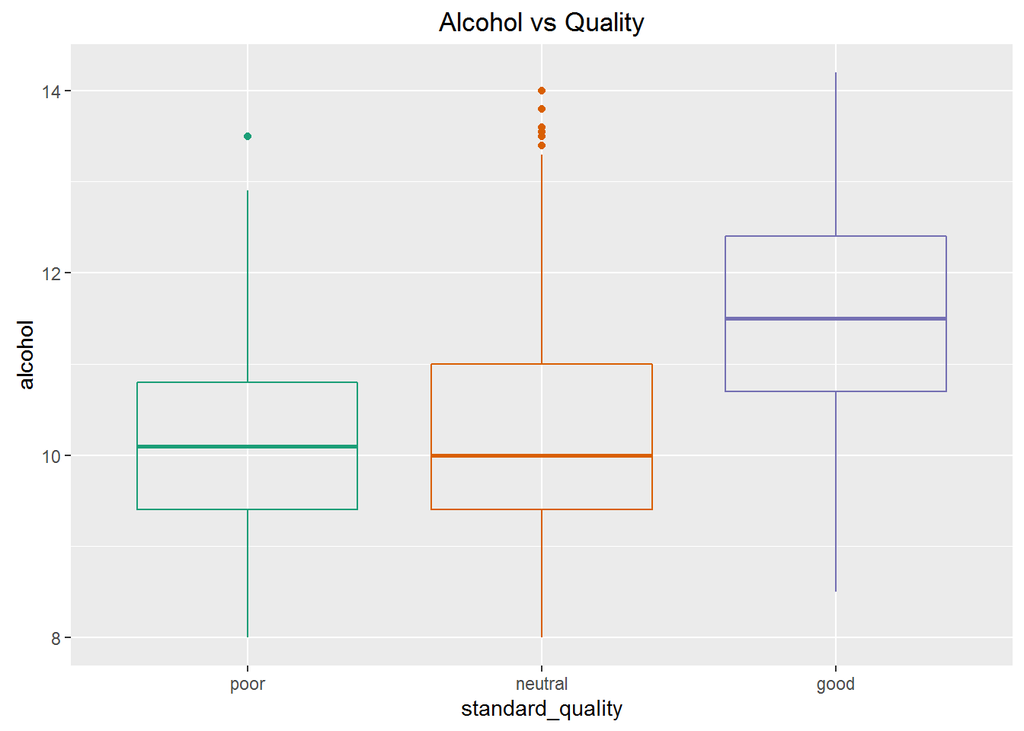

```
##
##    poor neutral    good
##     183    3655    1060
```

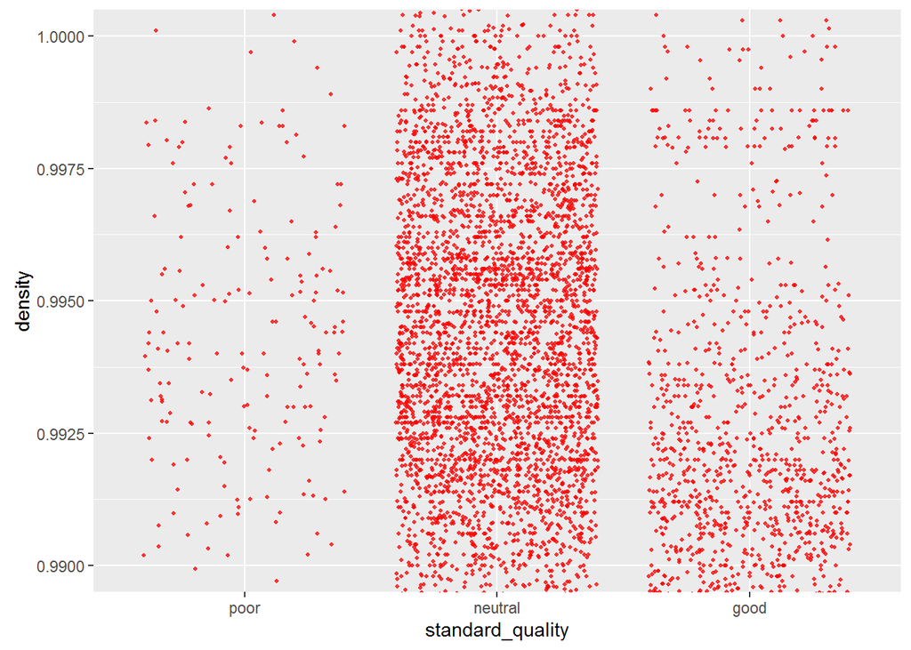

Density vs Quality Correlation

Density is negatively correlated to Quality (0.3071).Good wines seems to have lower density compared to average wines, however, the relationship is some what parabolic which shows they are not strongly negatively related (the median density of the good wines are the lowest with a median of 0.9917 g/cm3)

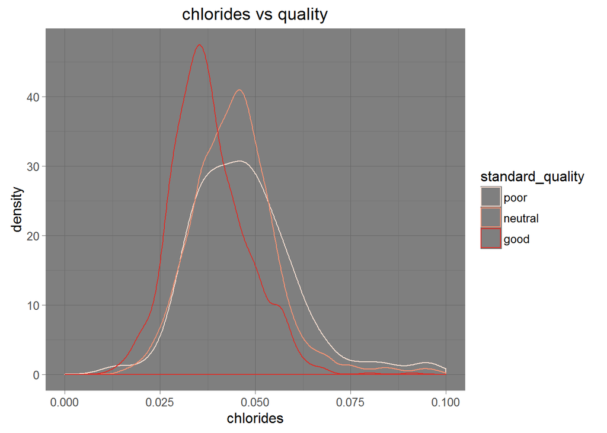

Chlorides vs Quality Correlation

Likewise, Chlorides is negatively correlated to quality and has a coefficient of correlation of 0.2099. The good quality wines have the lowest median chloride amount, compared to the poor and neutral quality wines. The median chloride amounts are not distinctly apart from each other.

Corelation Visualization (Correlogram)

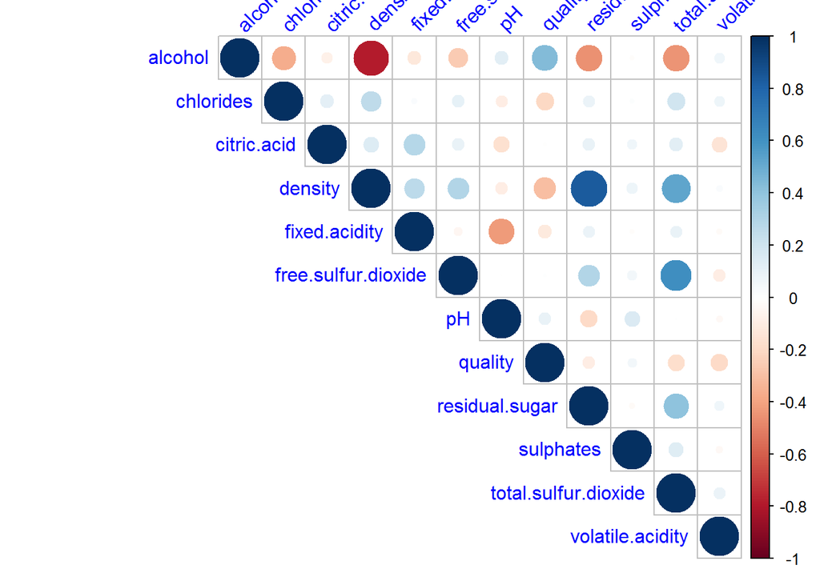

Density vs Alcohol Correlation

```
##
##  Pearson's product-moment correlation
##
## data:  White_wine$density and White_wine$alcohol
## t = -87.255, df = 4896, p-value < 2.2e-16
## alternative hypothesis: true correlation is not equal to 0
## 95 percent confidence interval:
##  -0.7908646 -0.7689315
## sample estimates:
##        cor
## -0.7801376
```

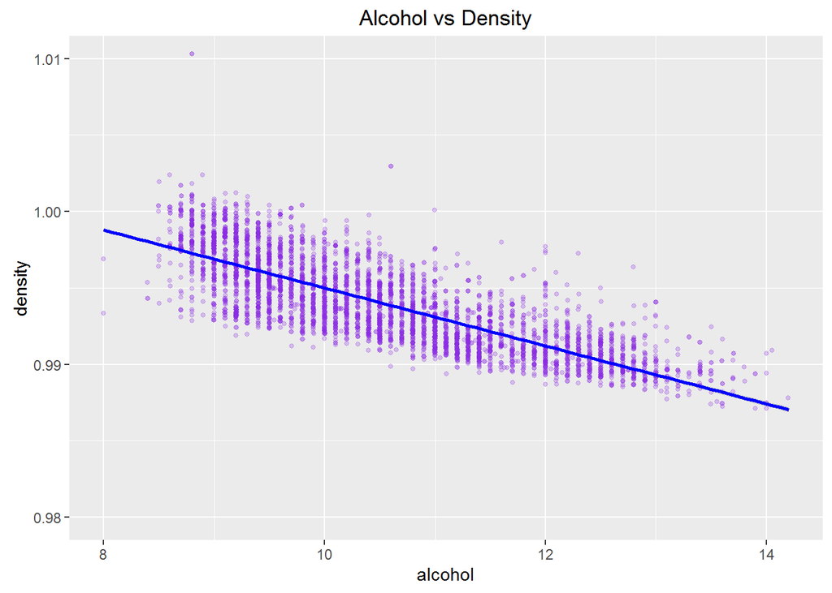

Alcohol and density has the strongest negative correlation of -0.7801, resulting to a decreas in density as the alcohol content of a wine increases.

Residual Sugar vs Density Correlation

```
##
##  Pearson's product-moment correlation
##
## data:  White_wine$density and White_wine$residual.sugar
## t = 107.87, df = 4896, p-value < 2.2e-16
## alternative hypothesis: true correlation is not equal to 0
## 95 percent confidence interval:
##  0.8304732 0.8470698
## sample estimates:
##       cor
## 0.8389665
```

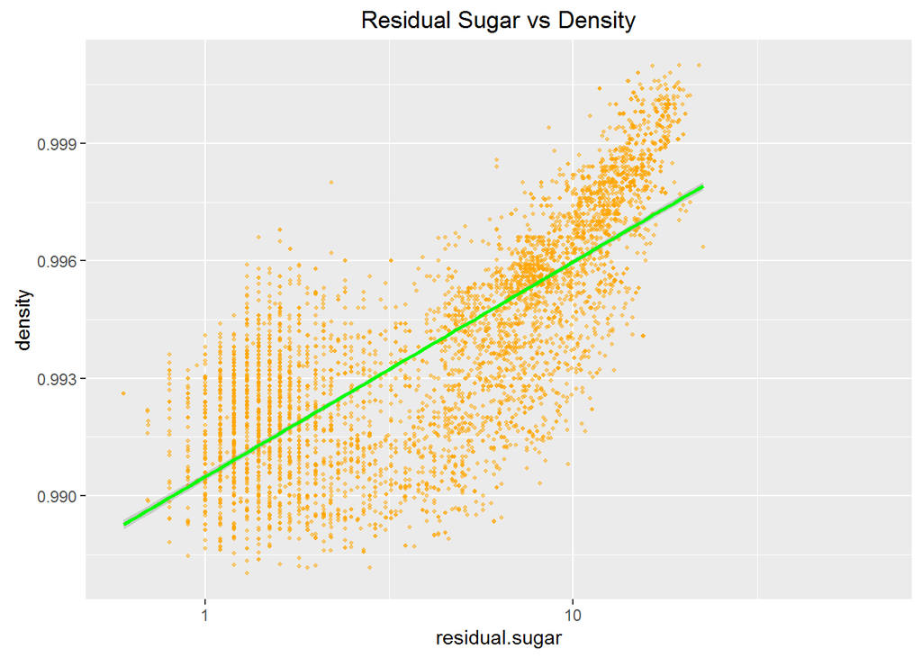

Density tends to increase as the Residual Sugar increases.

Fixed Acidity vs pH correlation

```
##
##  Pearson's product-moment correlation
##
## data:  White_wine$fixed.acidity and White_wine$pH
## t = -32.934, df = 4896, p-value < 2.2e-16
## alternative hypothesis: true correlation is not equal to 0
## 95 percent confidence interval:
##  -0.4485154 -0.4026542
## sample estimates:
##        cor
## -0.4258583
```

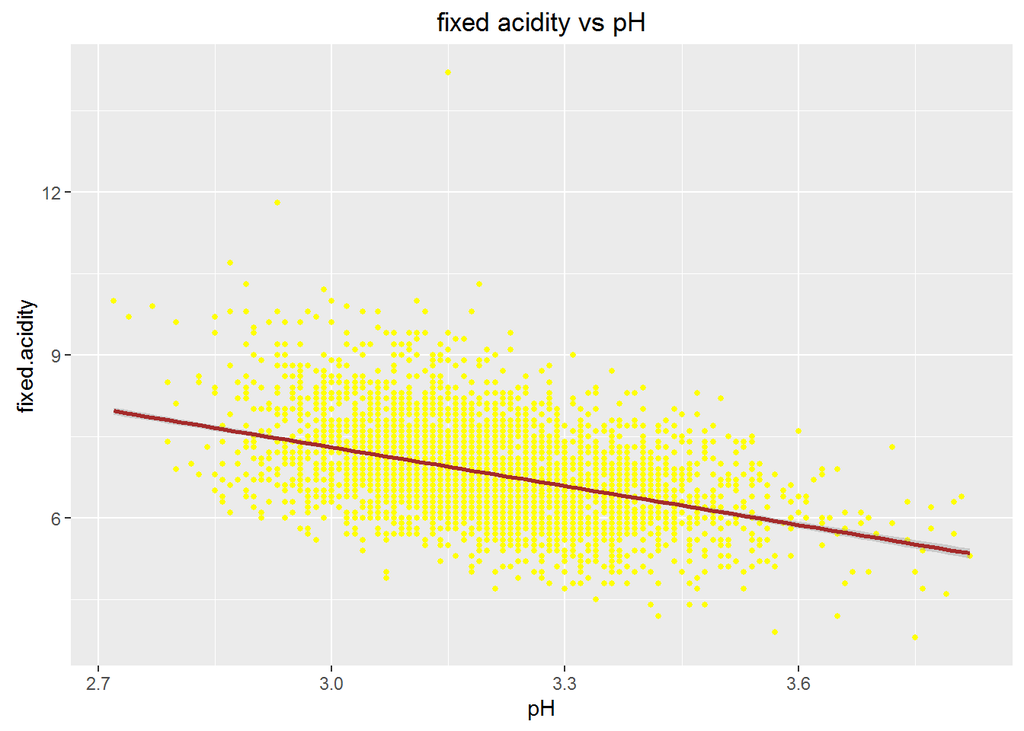

# Bivariate Analysis

### Relationships among various attributes

The residual sugar and density have a high positive correlation of 0.84 while the alcohol and density has a negative correlation of -0.78. Given that the fermentation process produces alcohol from the sugar, the more alcohol is produced, the less residual sugars are present.

### The strongest relationship noticed

The residual sugar and density have a high positive correlation of 0.84, followed by alcohol and density with a negative correlation of -0.78.

# Multivariate Plots Section

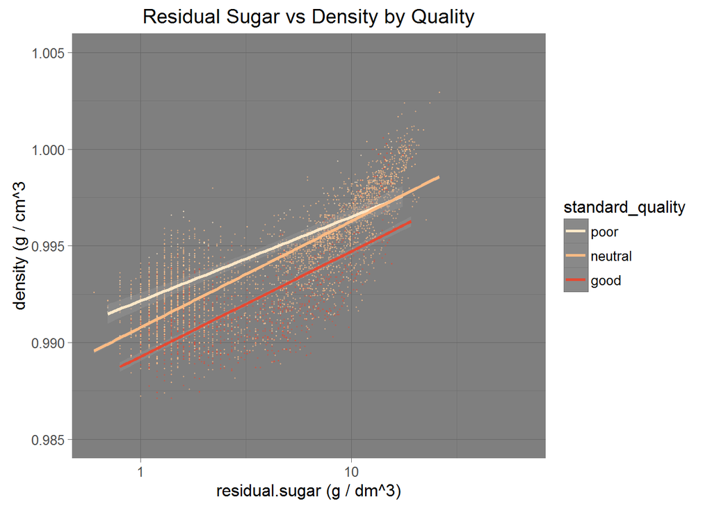

Wine of good quality tends to have a lower density. This could be due to the fact that alcohol content is more during ferementation leaving less sugar residual.

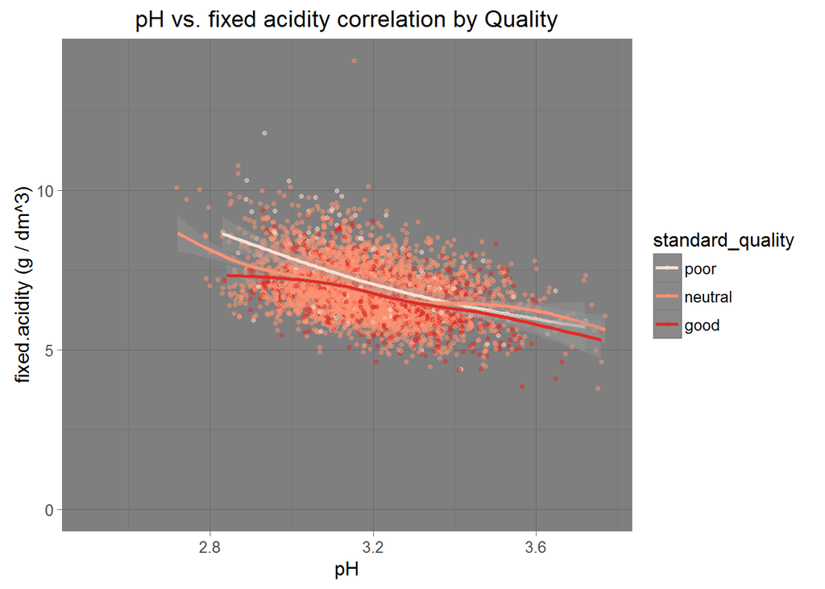

As fixed acidity increases, the pH declines. Although the correlation cofficient shows a strong negative relation , quality of wine doesn’t seem to be affected greatly as the trend shows over crossing of values.

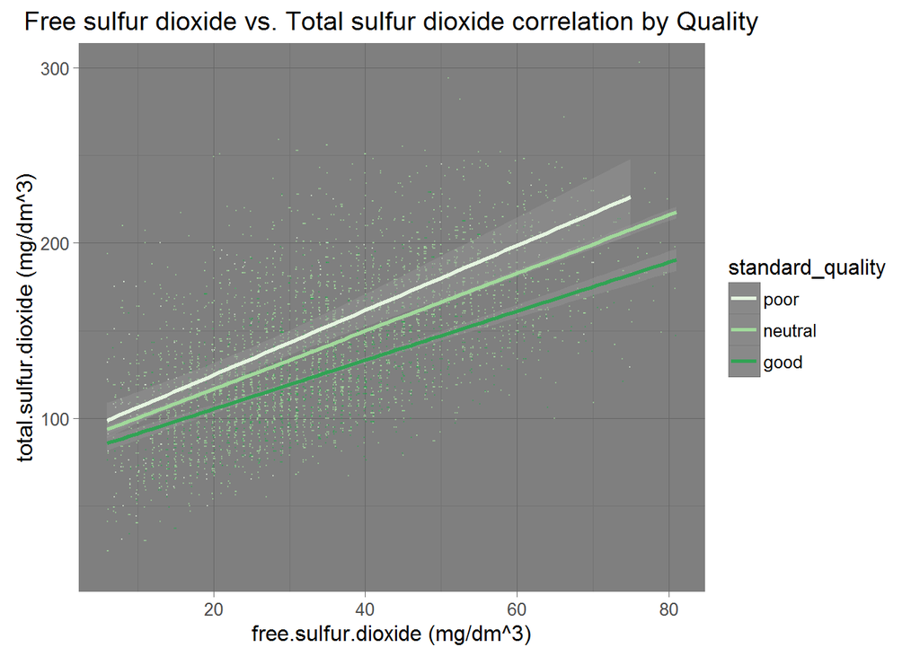

# Multivariate Analysis

### Observed relationships and features that strengthened each other to affect Quality

Generally speaking, alcohol seemed to be crucial in playing a role to bring a better quality of wine. However, I found out not only alcohol, but also density and residual sugar play a vital role.

# Final Plots and Summary

### Plot One

```
##    Min. 1st Qu.  Median    Mean 3rd Qu.    Max.
##   0.600   1.700   5.200   6.391   9.900  65.800
```

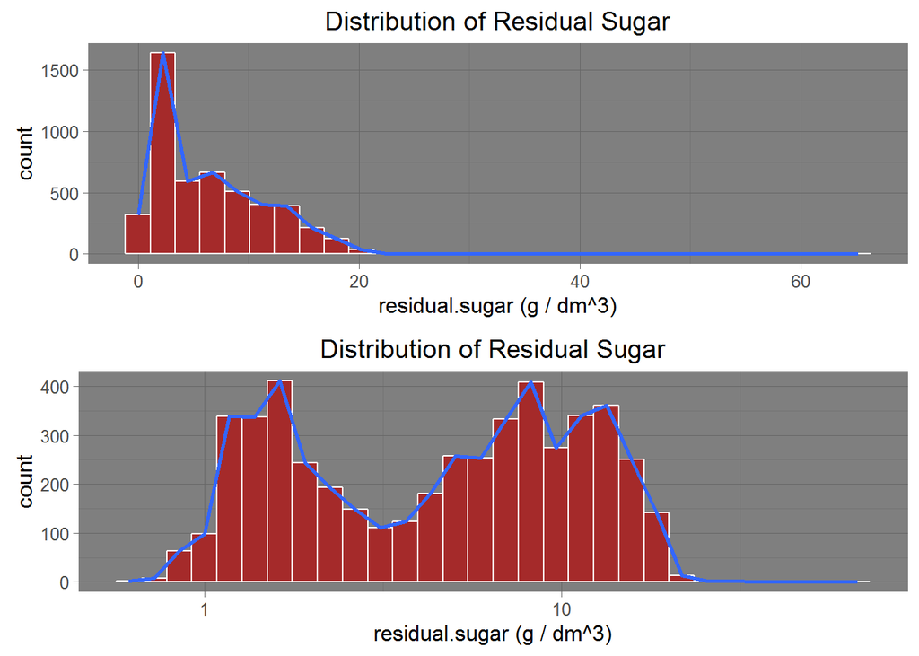

### Description One

The residual sugar distribution in white wines is highly skewed to the right (with a wide range of 0.6 g/l and 65.8 g/l). The average sugar level in white wine is 6.39g/l and a median of 5.2g/l and with a peak of between 1 to 2g/l. Inorder to make residual sugar observations normally distributed, both logarithmic (base 10) and square root transformations is done, in which the log transformation prefered to be the best one. Hence,residual sugar observations ended up being a bimodal distribution, almost grouped into less sweeter and more sweeter wines.

### Plot Two

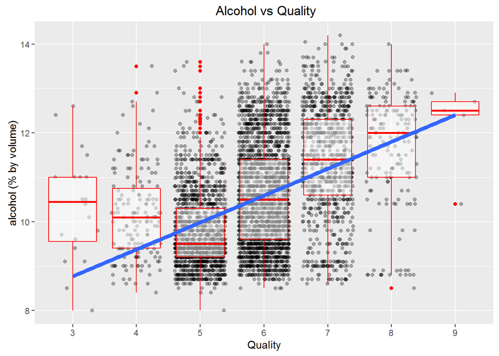

### Plot Three

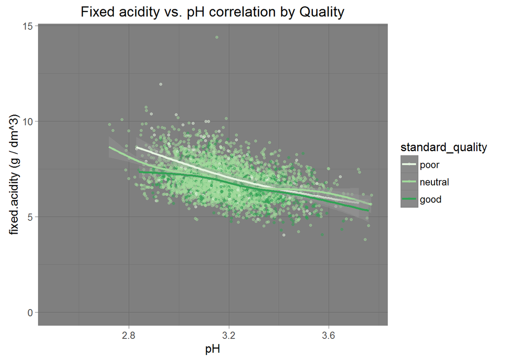

# Reflection

The correlation coefficient was helpful to make me be selective and focus on the pair of variables that are strongly correlated (positively or negatively). Exploration of other variables against the main feature of interest (Quality) in my dataset helped me to get a clue on the trend of relationship between variables. Yet, it was not easy for me to grasp the trends of all possible correlation outcomes with regard to quality. Once I categorized quality, it made my exploration very meaningful. Instead of making comparison with 7 levels of quality that range from 3 to 9, categorizing the quality into 3 buckets of quality, namely “poor”, “neutral” and “good” made my analysis easy to understand the trend between variables.

Yet, from my data exploration experience I understand that in order to do wine quality analysis, relying on the notion of correlation of the different variables alone, won’t help me get the best outcome out of the analysis there. There are certain variables which may not be correlated but still can play a role. To better understand the relationship between variables and predict wine quality, I would like to do further investigation using regression analysis for quality forecasting and modeling the relationship between the variables.

References:

1. http://www.sthda.com/english/wiki/correlation-matrix-a-quick-start-guide-to-analyze-format-and-visualize-a-correlation-matrix-using-r-software
2. http://stackoverflow.com/questions/15282580/how-to-generate-a-number-of-most-distinctive-colors-in-r
3. https://www.r-bloggers.com/r-using-rcolorbrewer-to-colour-your-figures-in-r/